# Bio326_2025

MS and colleagues

2025-02

# 1 Overview of the tutorial

Using the data from the Nanopore sequencing you conducted,

🎯 **Goals of this session:**

- Compare the read length and quality between the experimental conditions
- Investigate how the read cleaning process affect the read yields
- Identify the genomic variants from the sequence data
- Interpret how the genomic variants affects the animal biologically

🎯 **We will learn:**

- How to use Sigma2 and conduct genome analysis
- Quality check, read filtering, mapping to the reference genome and variant calling
- How to interpret summary statistics of Nanopore sequence data
- How to identify and interpret genetic variants

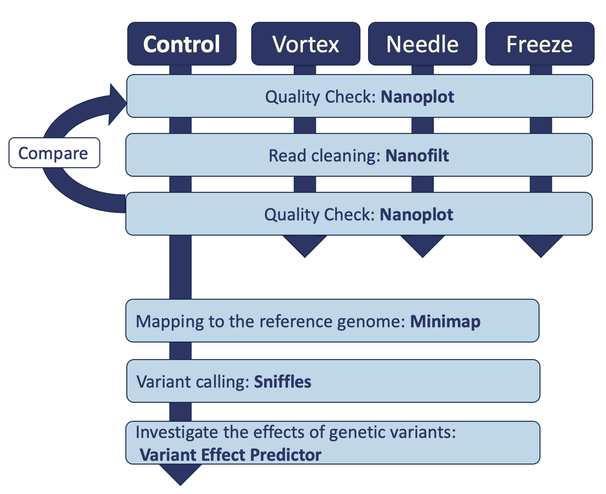

# 2 Day 1 Read quality check

🔎 Overview:

1. Quality check -> Trimming of low quality reads -> Quality check
2. Compare the overall reads quality between conditions

## 2.1 Connect to Sigma2 and the prepare the tools

🚀In the Terminal/Command prompt, go to Sigma2 and your directory there.

[Let’s review how to do so](https://github.com/TheMEMOLab/Bio326-NMBU/blob/main/Doc/HPC-101-WorkingWithSigma2.md)

```bash
ssh yourID@saga.sigma2.no
```

Let’s make a directory for analysis and enter in it.

```bash
mkdir analysis # make directory "analysis"
cd analysis # set the current directory "analysis"
```

Now, you will inspect the fastq file from your experiment, which contains Nanopore read information.

## 2.2 Check the read quality by Nanoplot

### 2.2.1 Browse the inside of the read (fastq) file

Let’s learn how a fastq file (sequencing reads) looks using a sample file (1-A).

```bash
zcat /cluster/projects/nn9987k/BIO326-2025/day1/1-A.fq.gz | more
```

🔎 Now you are seeing the content of a fastq file. (.gz = compressed)

Each entry in a FASTQ files consists of 4 lines:

1. A sequence identifier with information about the sequencing run. (run time, run ID, cflow cell id … )
2. The sequence (the base calls; A, C, T, G and N).
3. A separator, which is simply a plus (+) sign.
4. The base call quality scores. These are Phred +33 encoded, using ASCII characters to represent the numerical quality scores.” [quality score sheet](https://learn.gencore.bio.nyu.edu/ngs-file-formats/quality-scores/)
- by [Illumina Knowledge](https://knowledge.illumina.com/software/general/software-general-reference_material-list/000002211)

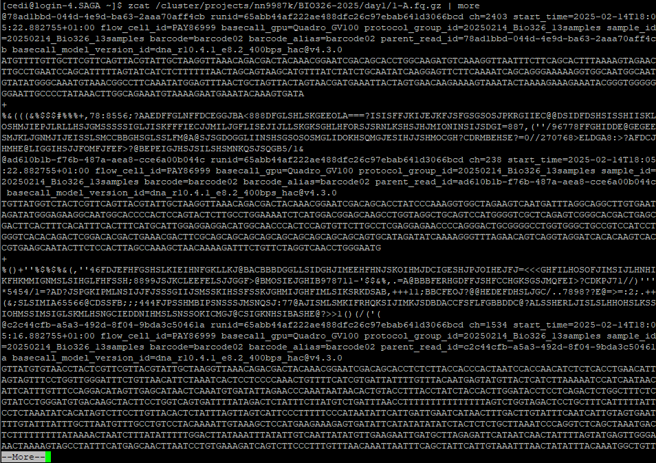

### 2.2.2 Get basic stats of the fastq file

“zcat”-> look inside

“wc” -> word count

“-l” -> line

```bash
zcat /cluster/projects/nn9987k/BIO326-2025/day1/1-A.fq.gz | wc -l
```

### 2.2.3 **Discussion Point**

🔎 Now you got the number of lines in the fastq file.

How many sequence reads are in the fastq file?

What is the quality of bp between 1 and 5? What is the quality of bp between 21 and 25? Why do you think they are different?

What is this species?

**Need Help? (click)**

We see that there are 364544 lines in the fastq file.

As we learned that “each entry in a FASTQ files consists of 4 lines”, one read is corresponding to four lines. So in this file we have 364544/4 = 91136 reads.

Hint for the 5 first bp:

```bash
zcat /cluster/projects/nn9987k/BIO326-2025/day1/1-A.fq.gz | sed -n 4p | cut -c 1-5
```

## 2.3 Quality check by Nanoplot

The original fastq files may contain low quality reads. In this step, we will use “Nanoplot” to see the quality and lentgh of each read.

🛠 Make a slurm script to conduct the quality check on the sample file like below and run it.

[Review: make a slurm script and run it by sbatch](https://github.com/TheMEMOLab/Bio326-NMBU/blob/main/Doc/HPC-101-WorkingWithSigma2.md)

```bash
#!/bin/bash
#SBATCH --job-name=Nanoplot  # sensible name for the job
#SBATCH --mem=12G
#SBATCH --ntasks=1
#SBATCH --cpus-per-task=8
#SBATCH --output=nanoplot_before
#SBATCH --account=nn9987k
#SBATCH --time=20:00


##Activate conda environment
module load StdEnv
module load Miniconda3/23.10.0-1
source ${EBROOTMINICONDA3}/bin/activate


conda activate /cluster/projects/nn9987k/.share/conda_environments/EUK_DRY

echo "Working with this $CONDA_PREFIX environment ..."


## run nanoplot

NanoPlot -t 8  --fastq /cluster/projects/nn9987k/BIO326-2025/day1/1-A.fq.gz --plots dot  --no_supplementary --no_static --N50 -p before_filter_A1
```

Nanoplot will generate the result files, named “before_filter_A1”xxx. Lets look into them…

[Review: File transfer between Sigma2 and your computer](https://training.pages.sigma2.no/tutorials/hpc-intro/episodes/15-transferring-files.html)

```bash
# taking too long?
qlogin

cp /cluster/projects/nn9987k/BIO326-2025/day1/before_filter_A1NanoPlot-report.html  before_filter_A1NanoPlot-report.html
```

🔎 Open “before_filter_A1NanoPlot-report.html” on your local computer

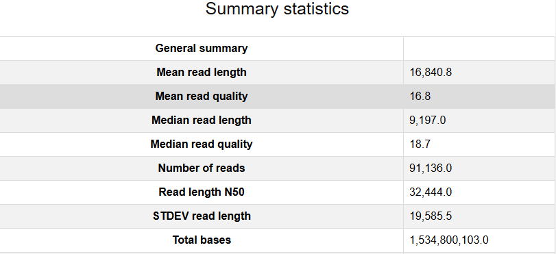

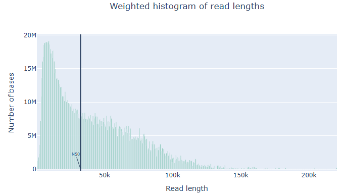

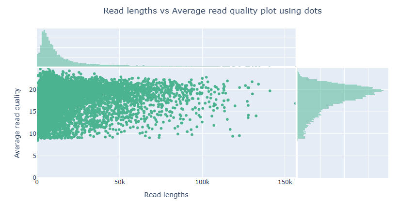

```bash
#!/bin/bash
#SBATCH --job-name=Nanofilt  # sensible name for the job
#SBATCH --mem=12G
#SBATCH --ntasks=1
#SBATCH --output=nanofilt
#SBATCH --account=nn9987k
#SBATCH --time=20:00


##Activate conda environment
module load StdEnv
module load Miniconda3/23.10.0-1
source ${EBROOTMINICONDA3}/bin/activate


conda activate /cluster/projects/nn9987k/.share/conda_environments/EUK_DRY

echo "Working with this $CONDA_PREFIX environment ..."


## run nanoplot
gunzip -c /cluster/projects/nn9987k/BIO326-2025/day1/1-A.fq.gz | NanoFilt -q 12 -l 1000 | gzip > cleaned_A1.fq.gz
```

This script activates a Conda environment (Your toolkit that Arturo pre-assembled) on a computing cluster:

1. Load required modules

module load StdEnv → Loads the standard environment.

module load Miniconda3/23.10.0-1 → Loads Miniconda, a lightweight Conda distribution.

2. Activate Conda

source ${EBROOTMINICONDA3}/bin/activate → Activates Miniconda.

conda activate EUK_DRY → Activates a specific Conda environment for the project.

3. Confirm activation

echo “Working with this $CONDA_PREFIX environment …” → Indicates the currently active Conda environment.

**Parameters**

-l, Filter on a minimum read length

-q, Filter on a minimum average read quality score

In this case, we are removing reads lower than quality score 12 and shorter than 1000 bases.

If you are ambitious, please adjust the filtering parameters and see how they change the result.

**(In that case, do not forget to name the result files differently.)**

## 2.4 Compare the sequences before and after cleaning

🚀 Run Nanoplot again on the cleaned sequences.

**Need help? (click)**

```bash
#!/bin/bash
#SBATCH --job-name=Nanoplot  # sensible name for the job
#SBATCH --mem=12G
#SBATCH --ntasks=1
#SBATCH --cpus-per-task=8
#SBATCH --output=nanoplot_after
#SBATCH --account=nn9987k
#SBATCH --time=20:00


##Activate conda environment
module load StdEnv
module load Miniconda3/23.10.0-1
source ${EBROOTMINICONDA3}/bin/activate


conda activate /cluster/projects/nn9987k/.share/conda_environments/EUK_DRY

echo "Working with this $CONDA_PREFIX environment ..."


## run nanoplot

NanoPlot -t 8  --fastq cleaned_A1.fq.gz --plots dot  --no_supplementary --no_static --N50 -p after_filter_A1
```

🔎 Open “after_filter_A1NanoPlot-report.html” on your local computer.

[figure not shown]

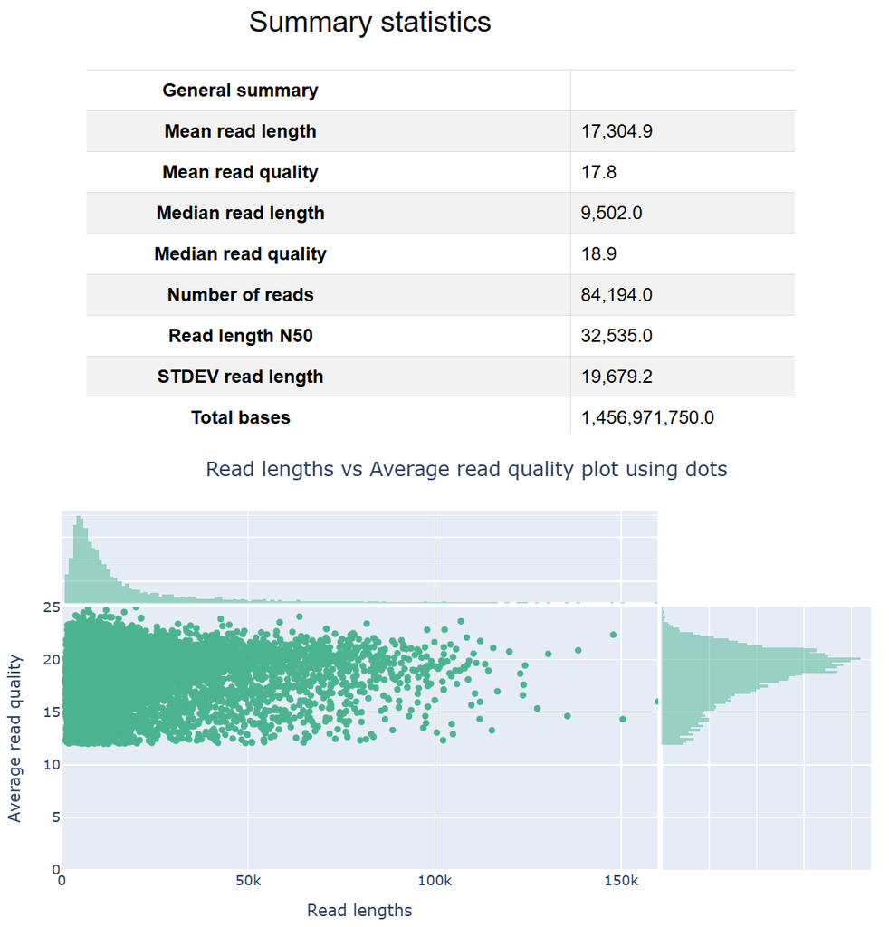

```bash
# taking too long?
qlogin

cp /cluster/projects/nn9987k/BIO326-2025/day1/after_filter_A1NanoPlot-report.html after_filter_A1NanoPlot-report.html
```

### 2.4.1 **Discussion Point**

- 1. Did you see the difference of read and quality distribution between before and after the filtering? Discuss within/between groups.
- 2. What species is this? (That should be Eukaryote)

Hint 1 ⚠️ **Notice!** The first few thousand reads might be short/unreliable.

**Hint 2 🔍 Try looking at the **2001st read** (click)**

```bash
zcat cleaned_A1.fq.gz | tail -n +2001 | awk 'NR%4==2 && length($0) > 1000' | head -1
```

**Result: the **2001st read** (click)**

```bash
TGCCACTTACTTCGTTCAGTTACGTATTGCTAAGGTTAAACAGACGACTACAAACGGAAT…
```

**Hint 3 (click)**

🧬 Run a [**nucleotide BLAST search**](https://blast.ncbi.nlm.nih.gov/Blast.cgi?PROGRAM=blastn&PAGE_TYPE=BlastSearch&LINK_LOC=blasthome) to search the sequence against a public genetic database.

**Hint 4 (click)**

🐄 **Many hits are from …what species…? And one species looks obviously different! What is it??**

**Result**

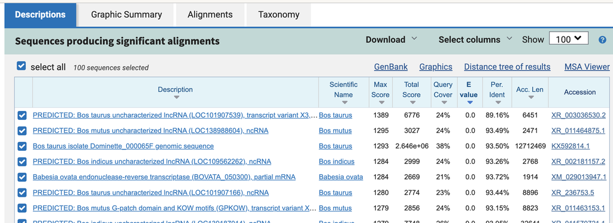

## 2.5 **Your mission**

Do the quality check and filtering, and compare the read length and quality between the four experimental conditions you have conducted!!

# 3 Day2 Mapping to the reference genome

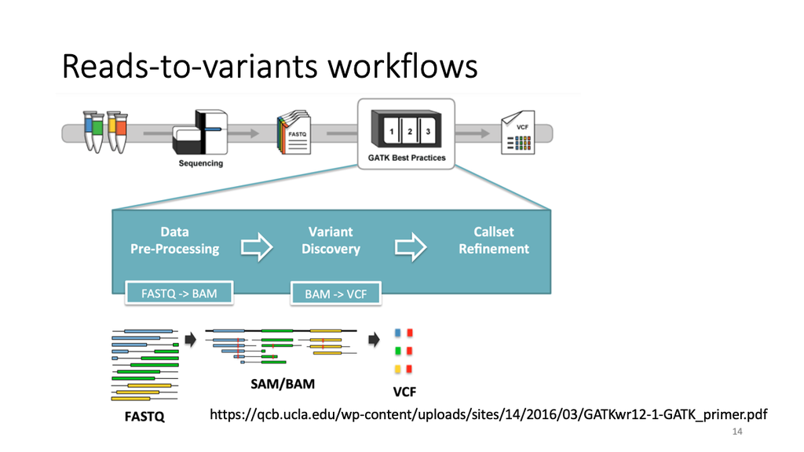

### What is Read Mapping?  
- Aligning sequencing reads to a reference genome.  
- Essential for variant detection to find out which region is different from your sample and standard sample.

## 3.1 run Minimap and map the reads to the reference genome

```bash
#!/bin/bash
#SBATCH --job-name=Sniffles # sensible name for the job
#SBATCH --mem=12G
#SBATCH --ntasks=1
#SBATCH --cpus-per-task=8
#SBATCH --output=mapping
#SBATCH --account=nn9987k
#SBATCH --time=20:00

##Activate conda environment
module load StdEnv
module load Miniconda3/23.10.0-1
source ${EBROOTMINICONDA3}/bin/activate

echo "Working with this $CONDA_PREFIX environment ..."


minimap2 -t 8 -a /cluster/projects/nn9987k/BIO326-2025/Bos_taurus.ARS-UCD1.3.dna.toplevel.fa.gz  /cluster/projects/nn9987k/BIO326-2025/day2/cleaned_control.fastq.gz > control.sam


# convert the sam file to bam format
samtools view -S -b control.sam > control_temp.bam

## sort the bam file
samtools sort control_temp.bam -o control.bam

# index the bam file
samtools index -M  control.bam

# Variant Calling using Sniffles
sniffles --input  control.bam --vcf control.vcf
```

## 3.2 The Sniffles Variant Calling Script

| **Command** | **Explanation** |
| --- | --- |
| `#!/bin/bash` | Declares that this script should be executed using the Bash shell. |
| `#SBATCH --job-name=Sniffles` | Names the job “Sniffles” in the SLURM job scheduler. |
| `#SBATCH --mem=12G` | Allocates 12GB of memory for the job. |
| `#SBATCH --ntasks=1` | Requests 1 task (single execution unit). |
| `#SBATCH --cpus-per-task=8` | Allocates 8 CPU cores for the task. |
| `#SBATCH --output=mapping` | Specifies the output log file name as `mapping`. |
| `#SBATCH --account=nn9987k` | Uses project account `nn9987k` for resource allocation. |
| `#SBATCH --time=20:00` | Sets a time limit of 20 minutes for the job. |

### 3.2.1 What is Variant Calling?

- Identifying differences between sequenced DNA and a reference genome.
- Important for studying mutations and genetic variation.  
  [bam and sam format](https://labs.epi2me.io/reviewing-bam/)

Note: Mapping and variant calling is time consuming, but you can find the output file here: /cluster/projects/nn9987k/BIO326-2025/day2/control.vcf

Now you got the variant file!

# 4 🔍Investigate the variants

- Celian will explain how to read a vcf file  
  Go to mentimeter: https://www.menti.com/al74tk7yrm9h (or use code 7641 4896)

Copy the vcf in your directory

```bash
qlogin

cp /cluster/projects/nn9987k/BIO326-2025/day2/control.vcf  control.vcf
```

Look inside the vcf

```bash
# INFO field

grep '^##' control.vcf | tail -n 20

# variants
grep -v '^##' control.vcf | more
```

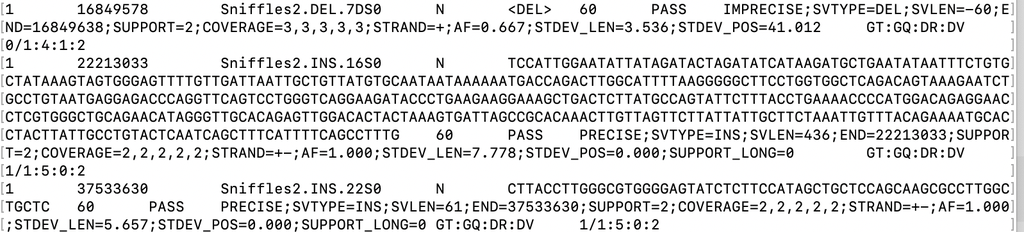

Important parameters

1 16849578 : location of the variant

SVTYPE=DEL;SVLEN=-60 : size and type of the variant

0/1 : genotype

(you can open a vcf file in notepad, excel etc.)

| **field** | **Explanation** |
| --- | --- |
| CHROM | Chromosome name |
| POS | Variant position |
| REF | Reference allele (reference version) |
| ALT | Alternate allele (your sample’s version) |

Now you have variants! Lets see which genes are affected by the variants.

Since there are many variants it can be difficult to know where to start

Let’s select a random variant for yourself to investigate.

```bash
#Check the number of variant in the file

NBVAR=$(grep -v '^##' control.vcf | wc -l)

## sample a random number

RANDOMVAR=$(echo $((RANDOM % $NBVAR + 1)))

## let's check the variant sampled

grep -v '^##' control.vcf |  sed -n ${RANDOMVAR}p
```

## 4.1 🔍Estimate the effect of variants (!contains spoiler!)

[Go to VEP (Variant Effect Predictor)](https://www.ensembl.org/Tools/VEP)

Variant Effect predictor tells us where in the genome the discovered variants are located (genic, regulatory, etc…)

Select “cow” as the reference species.

Upload: control.vcf - downloaded from Sigma2 or the section above as the file to investigate.

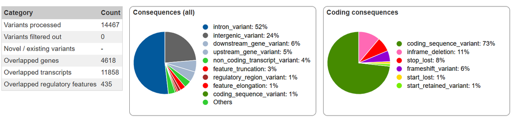

There are 14467 variants; 4618 genes are affected by these varaints.

Let’s closely investigate your variant !

Find your variant by downloading the .txt file

Hint: Open the file in textedit or Excel and use Ctrl+F and paste the ID of your variant, which can be find in the vcf file.

If you don’t find your variant, what does that mean? Try another one!

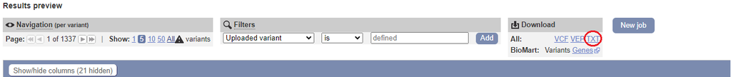

What does your variant look like in the sequence ?

[We can look at it on IGV](https://igv.org/)

Select the cow reference genome - ARS-UCD1.2/bosTau9

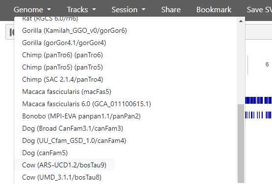

Then import the vcf from your computer

[figure not shown]

You can select the chromosome and put the location of your variant to look at it !

Hint: remember the location of your variant is in the vcf file

[figure not shown]

🏆That’s it ! You are now expert in genome analysis !🏆

If you’re considering undertaking a similar bioinformatics/genomics project for your master’s thesis, you can [contact our lab](https://sites.google.com/view/saitou-lab/home)